# Reporte

Martha Ines Juarez Cabrera

12/12/2021

Es evidente que la incidencia delictiva y la percepción de la seguridad en México están relacionadas, podemos observar que con la información recolectada en el último año que las Entidades con mayor casos de crímenes presentan una mayor porcentaje percepción de inseguridad y un menor porcentaje de confianza en la policía.

### Resultados

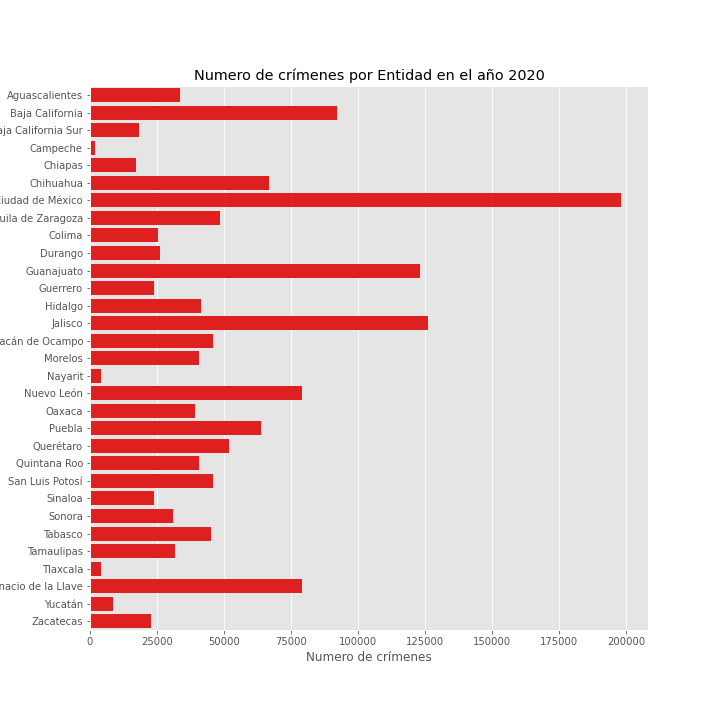

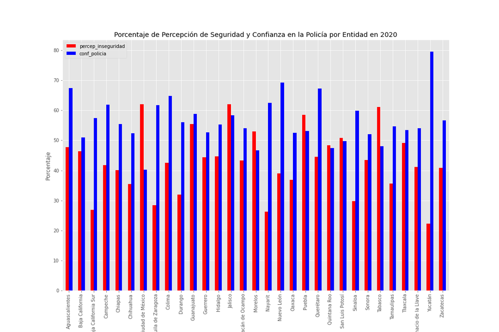

Tomemos como ejemplo a la Ciudad de México en donde es evidente que en 2020 se tuvo una gran incidencia delictiva. Observemos en la segunda gráfica que CDMX tiene un porcentaje de percepción de inseguridad alto comparado con el porcentaje de confianza en la policía. Lo mismo sucede para Jalisco.

Si bien Tamaulipas no presenta una gran incidencia delictiva para el 2020, la diferencia entre el porcentaje de percepción de inseguridad y de confianza en la policía es muy grande. Recordemos que Tamaulipas tiene una población de 3.5 millones, casi 2.5 veces menor que en CDMX.

Yucatán forma parte de los 5 estados con menor incidencia delictiva del 2020 y esto puede verse reflejado en la percepción de seguridad y confianza en la policía. Esta misma relación se presenta en Campeche, Chiapas y Nayarit.

Ahora, analicemos la gráfica de la Tasa de Inseguridad por localidad, municipio y estado.

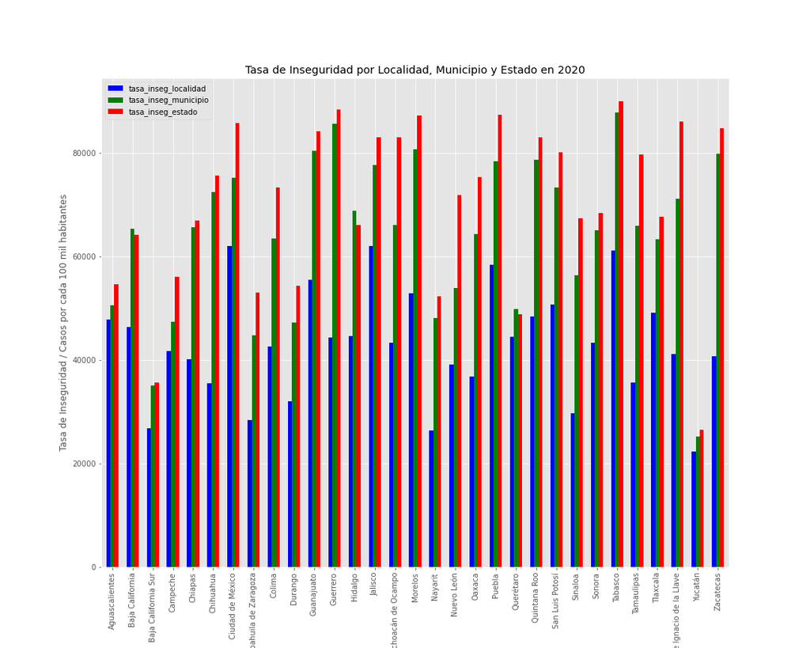

## Conclusión

En definitiva la incidencia delictiva en México ha suscitado que la percepción de inseguridad en el país sea alarmante para algunas Entidades de la República Mexicana.